# Hw1GoogleAnalytics

Bryan Tamsir, Erik Chu, Hariz Mohd Rani Hisham, Yi-Yun Su

1/22/2019

```r
#Set WD
rm(list = ls()) #to clear global environment
library(data.table)
```

```r
dtsum = fread("~/Documents/Academic/MA/hw1/GoogleMerchandise2016_2017_summary.csv")
dthits = fread("~/Documents/Academic/MA/hw1/GoogleMerchandise2016_2017_Hits.csv")
```

### Question 1

1. What share of visits with products added to cart end in a purchase?

We set the keys as fullVisitorId, visitId, and hitNumber We subsetted the hits data for action types 3 and 6 Merge both data tables and grouped by fVId and vId

```r
# Create new Data Table
uniqueN(dthits[, .(fullVisitorId, visitId, hitNumber)] ) / dthits[,.N]
```

```
## [1] 1
```

```r
setkey(dthits, fullVisitorId, visitId, hitNumber)

table(dthits$action_type)
```

```
##
##       0       1       2       3       4       5       6
## 3006157      55  359752      67       5   87946   24484
```

```r
#67 # for actiontype 3
#24484 for actiontype 6

#Subset into appropriate data table and set the key for each.
purchase = dthits[action_type==6, .(fullVisitorId, visitId, action_type) ]
addtocart = dthits[action_type==3, .(fullVisitorId, visitId, action_type) ]
checkout = dthits[action_type==5, .(fullVisitorId, visitId, action_type) ]

#Set keys for all data tables
setkey(purchase, fullVisitorId, visitId, action_type)
setkey(addtocart, fullVisitorId, visitId, action_type)
setkey(checkout, fullVisitorId, visitId, action_type)

final = merge(addtocart, purchase, by=c("fullVisitorId", "visitId"), all.x = TRUE)
onea = sum(final$action_type.y == 6, na.rm = T) / sum(final$action_type.x == 3) #for some reason the first half does not work
onea
```

```
## [1] 0.05797101
```

```r
#answer is 5.797%
```

### Question 1b

1b. What share of visits with a “Check out"” end in a purchase?

```r
finalb = merge(checkout, purchase, by=c("fullVisitorId", "visitId"), all.x = TRUE, allow.cartesian=TRUE)
oneb = sum(finalb[!is.na(action_type.y), .N]) / sum(finalb$action_type.x == 5)
oneb
```

```
## [1] 0.8404345
```

```r
# answer is 84%
```

### Question 2

What is the distribution of time from the start of a session to when a purchase is made? Plot hist, mean, min, max, median.

Subset on action type 6 (purchases) from hits table Set keys Divided time by 60000 to convert ms to minutes View histogram

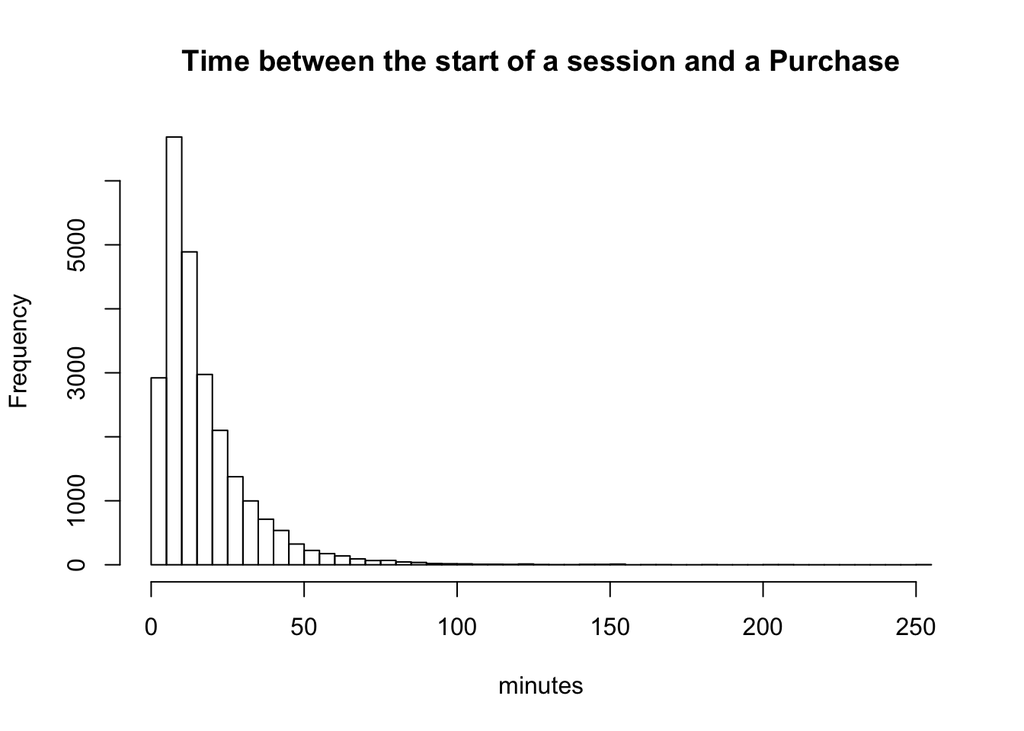

```r
time1 = dthits[action_type == 6, .(fullVisitorId, visitId, action_type, time, hitNumber) ]
setkey(time1, fullVisitorId, visitId, hitNumber)
hist(
  time1$time / 60000,
  breaks=50,
  main="Time between the start of a session and a Purchase", xlab="minutes")
```

```r
summary(time1$time / 60000) #in minutes
```

```
##    Min. 1st Qu.  Median    Mean 3rd Qu.    Max.
##   0.000   7.279  12.450  17.246  21.932 250.777
```

### Question 3

Q3 - What is the distribution of time from “Check out” to “purchase made”? Plot the histogram and report the min, max, mean and median.

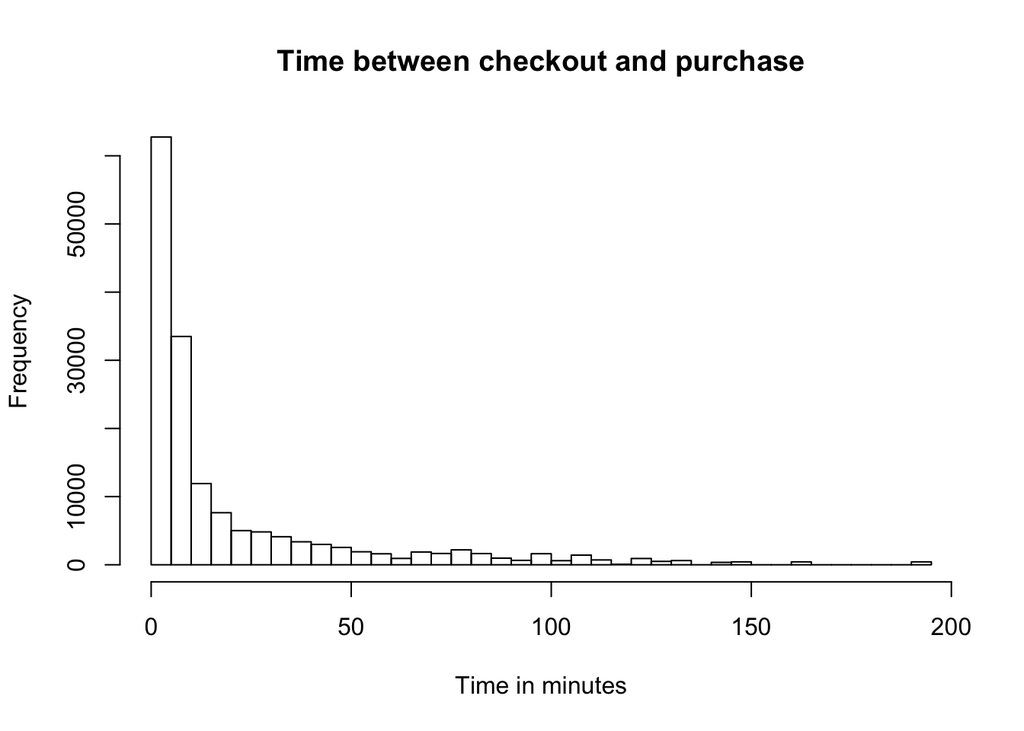

```r
purchase3 = dthits[action_type == 6, .(fullVisitorId, visitId, action_type, time) ]

dthits[action_type == 5, time1 := min(time), .(fullVisitorId, visitId)]
checkout3 = dthits[action_type==5, .(fullVisitorId, visitId, action_type, time1) ]

setkey(purchase3, fullVisitorId, visitId)
setkey(checkout3, fullVisitorId, visitId)

temp = merge(checkout3, purchase3,
                  by = c("fullVisitorId", "visitId"),
                  all.x = TRUE,
                  allow.cartesian = TRUE)
question3 = temp[complete.cases(temp), ]
question3[ , timeDiff := ifelse((time - time1) > 0, time- time1, NA)]
question3$timeDiff = question3$timeDiff / 60000

hist(
  question3[, timeDiff],
  breaks = 50,
  main = "Time between checkout and purchase", xlab = "Time in minutes")
```

```r
summary(question3$timeDiff)
```

```
##     Min.  1st Qu.   Median     Mean  3rd Qu.     Max.     NA's
##   0.1571   3.3899   6.8619  21.1507  23.9051 190.2054       26
```

### Question 4

What are the bounce rates for the ten largest landing pages (largest by number of visits.) (Hint: this will require you to merge the “Hits” and “Summary” data sets. See the document “data.table-Keys-andMerge.Rmd” for help.)

Merge hits with summary on fVId and vId Calculated number of obs for each unique landing screen name Calculated bounces rates for each unique landing screen name Output: List of landing screen names, bounce rate associated, no. of obs.

```r
hits_4 <- merge(dtsum,
                dthits[, .(fullVisitorId, visitId, hitNumber, landingScreenName)],
                by = c("fullVisitorId", "visitId"))

hits_4[, .(bouncerate = sum(bounces, na.rm = T) / .N, N_obs = .N),
       landingScreenName][order(-N_obs)][1:10]
```

```
##                                                                  landingScreenName
##  1:                                           shop.googlemerchandisestore.com/home
##  2:                                            www.googlemerchandisestore.com/home
##  3:          shop.googlemerchandisestore.com/google+redesign/shop+by+brand/youtube
##  4: shop.googlemerchandisestore.com/google+redesign/apparel/men++s/men++s+t+shirts
##  5:                                    shop.googlemerchandisestore.com/signin.html
##  6:                                    shop.googlemerchandisestore.com/basket.html
##  7:     shop.googlemerchandisestore.com/google+redesign/apparel/mens/mens+t+shirts
##  8:                                         shop.googlemerchandisestore.com/home-2
##  9:                           shop.googlemerchandisestore.com/google+redesign/bags
## 10:                      shop.googlemerchandisestore.com/google+redesign/drinkware
##     bouncerate   N_obs
##  1: 0.07854788 1320163
##  2: 0.19371081 1039307
##  3: 0.18997903  242232
##  4: 0.08820603  104528
##  5: 0.09247823   63961
##  6: 0.06991704   61716
##  7: 0.11906339   51334
##  8: 0.01627459   39448
##  9: 0.10777817   36371
## 10: 0.13390674   35577
```